# Assignment 3

Aria Lu and Gloria Zhou

2024-10-11

```r
url <- "https://en.wikipedia.org/wiki/Grand_Boulevard,_Chicago"
html_page <- read_html(url)
```

Notice that the table containing the results we need have a html tag `table`and class `us-census-pop`.

```r
pop <- html_page %>%
  html_element(css = "table.us-census-pop") %>%
  html_table() %>%
  dplyr::select(Census, Pop. , `%±`)
```

Find the index of adjacent table:

```r
tables <- html_page %>% html_nodes("table")

for (i in seq_along(tables)) {
  table_text <- html_text(tables[[i]])
  if (grepl("Places adjacent to Grand Boulevard, Chicago", table_text)) {
    print(paste("The correct table is at position", i))
    correct_table <- tables[[i]]
    break
  }
}
```

```
## [1] "The correct table is at position 3"
```

Since the places in the east are listed in the third column, we use css selector `tr td:nth-child(3)` to match the third column.

Additionally, the places are with a link, therefore, change the css selector to `tr td:nth-child(3) a`:

```r
place_elements <- html_elements(correct_table, css = "tr td:nth-child(3) a")
```

Get the `href` attribute from the `a` tag elements. Combine with the base url:

```r
places <- data.frame(
  place = html_attr(place_elements, "title"),
  href = html_attr(place_elements, "href")
) %>%
  mutate(url = paste0("https://en.wikipedia.org", href))
```

Get the census pop table for each page and combine them into a list with names:

```r
get_census_pop <- function(url) {
  url %>%
    read_html() %>%
    html_element(css = "table.us-census-pop") %>%
    html_table() %>%
    dplyr::select(Census, Pop. , `%±`)
}

pops <- c(list(pop), lapply(places$url, get_census_pop))
names(pops) <- c("Grand Boulevard, Chicago", places$place)
```

Add a column about the place’s name for each sub-table:

```r
pops <- lapply(
  seq_along(pops),
  function(i) {
    pops[[i]] %>%
      mutate(Place = names(pops)[i])
  }
)
```

Combine all the results:

```r
pops_longer <- purrr::reduce(pops, rbind) %>%
  mutate(Census = as.integer(Census),
         Pop. = stringr::str_replace(Pop., ",", ""),
         Pop. = as.integer(Pop.),
         `%±` = stringr::str_replace(`%±`, "%", ""),
         `%±` = stringr::str_replace(`%±`, "−", "-"),
         `%±` = as.numeric(`%±`) * 0.01) %>%
  dplyr::filter(!is.na(Census))
```

Reshape to a wider form:

```r
pops_longer %>%
  pivot_wider(id_cols = "Census",
              names_from = "Place",
              values_from = "Pop.") %>%
  arrange(Census) %>%
  knitr::kable()
```

| Census | Grand Boulevard, Chicago | Oakland, Chicago | Kenwood, Chicago | Hyde Park, Chicago |
| --- | --- | --- | --- | --- |
| 1910 | NA | 13763 | NA | NA |
| 1920 | NA | 16540 | NA | NA |
| 1930 | 87005 | 14962 | 26942 | 48017 |
| 1940 | 103256 | 14500 | 29611 | 50550 |
| 1950 | 114557 | 24464 | 35705 | 55206 |
| 1960 | 80036 | 24378 | 41533 | 45577 |
| 1970 | 80166 | 18291 | 26890 | 33531 |
| 1980 | 53741 | 16748 | 21974 | 31198 |
| 1990 | 35897 | 8197 | 18178 | 28630 |
| 2000 | 28006 | 6110 | 18363 | 29920 |
| 2010 | 21929 | 5918 | 17841 | 25681 |
| 2020 | 24589 | 6799 | 19116 | 29456 |

About the percentage of changes:

```r
pops_longer %>%
  pivot_wider(id_cols = "Census",
              names_from = "Place",
              values_from = "%±") %>%
  arrange(Census) %>%
  knitr::kable()
```

| Census | Grand Boulevard, Chicago | Oakland, Chicago | Kenwood, Chicago | Hyde Park, Chicago |
| --- | --- | --- | --- | --- |
| 1910 | NA | NA | NA | NA |
| 1920 | NA | 0.202 | NA | NA |
| 1930 | NA | -0.095 | NA | NA |
| 1940 | 0.187 | -0.031 | 0.099 | 0.053 |
| 1950 | 0.109 | 0.687 | 0.206 | 0.092 |
| 1960 | -0.301 | -0.004 | 0.163 | -0.174 |
| 1970 | 0.002 | -0.250 | -0.353 | -0.264 |
| 1980 | -0.330 | -0.084 | -0.183 | -0.070 |
| 1990 | -0.332 | -0.511 | -0.173 | -0.082 |
| 2000 | -0.220 | -0.255 | 0.010 | 0.045 |
| 2010 | -0.217 | -0.031 | -0.028 | -0.142 |
| 2020 | 0.121 | 0.149 | 0.071 | 0.147 |

```r
get_main_text <- function(html, collapse = TRUE) {
  selector <- c("div.mw-content-ltr > div.mw-heading > h1",
                "div.mw-content-ltr > div.mw-heading > h2",
                "div.mw-content-ltr > div.mw-heading > h3",
                "div.mw-content-ltr > div.mw-heading > h4",
                "div.mw-content-ltr > div.mw-heading > h5",
                "div.mw-content-ltr > div.mw-heading > h6",
                "div.mw-content-ltr > p:not(.mw-empty-elt)",
                "div.mw-content-ltr > ul",
                "div.mw-content-ltr > ol") %>%
    paste(collapse = ", ")

  text <- html %>%
    html_elements(css = "#mw-content-text") %>%
    html_elements(css = selector) %>%
    html_text(trim = TRUE) %>%
    stringr::str_replace_all("\\n", " ") %>%
    stringr::str_replace_all("\\[\\d*?\\]", "")
  if (collapse) return(paste(text, collapse = " "))
  else return(text)
}
```

```r
cat(get_main_text(html_page, collapse = FALSE), sep = "\n")
```

```
## Grand Boulevard on the South Side of Chicago, Illinois, is one of the city's Community Areas. The boulevard from which it takes its name is now Martin Luther King Jr. Drive. The area is bounded by 39th to the north, 51st Street to the south, Cottage Grove Avenue to the east, and the Chicago, Rock…
## Bronzeville
## This is one of the two community areas that encompass the Bronzeville neighborhood, with the other being Douglas. Grand Boulevard also includes the Washington Park Court District neighborhood that was declared a Chicago Landmark on October 2, 1991.
## The Harold Washington Cultural Center is one of its newer and more famous buildings. It arose on the site that from the 1920s through the 1970s housed a famous center of African American cultural life, the Regal Theater. Among the other notable properties in this neighborhood are the Daniel Hale …
## Demographics
## According to a 2018 US Census American Community Survey, there were 22,784 people and 10,383 households in Grand Boulevard. The racial makeup of the area was 92.56% African American, 2.70% White, 0.70% Asian, and 2.26% from other races. Hispanic or Latino residents of any race were 1.77% of the p…
## Education
## Grand Boulevard is part of City of Chicago School District #299 and City Colleges of Chicago District #508. The nearest City Colleges campus was Kennedy–King College in Englewood. A high school diploma had been earned by 85.5% of Grand Boulevard residents and a bachelor's degree or greater had be…
## Transportation
## The Chicago Transit Authority operates the Chicago "L" system in the Grand Boulevard community area. The Green Line provides rapid transit at four stations: Indiana, 43rd Street, 47th Street and 51st Street stations.
## Politics
## The Grand Boulevard community area has supported the Democratic Party in the past two presidential elections by overwhelming margins. In the 2016 presidential election, Grand Boulevard cast 10,081 votes for Hillary Clinton and cast 171 votes for Donald Trump. In the 2012 presidential election, Gr…
## Notable people
## Robert Sengstacke Abbott (1870–1940), founder of The Chicago Defender. He lived in Grand Boulevard from 1926 until his death in 1940. Noble Drew Ali (1886–1929), founder of the Moorish Science Temple of America. He resided at 3613 South Indiana Avenue at the time of his death. Sol Bloom (1870–194…
## External links
## Official City of Chicago Grand Boulevard Community Map  Bronzeville travel guide from Wikivoyage Bronzeville at Explore Chicago, The Official City of Chicago Tourism Website
## References
```

```r
descriptions <- places$url %>%
  sapply(function(url) get_main_text(read_html(url)))
descriptions <- c(get_main_text(html_page), descriptions)
descriptions <- tibble(
  name = c("Grand Boulevard, Chicago", places$place),
  description = descriptions
)
```

```r
library(tidytext)

data("stop_words")

tokens <- descriptions %>%
  unnest_tokens(word, description) %>%
  dplyr::filter(!(word %in% stop_words$word))
```

```r
tokens %>%
  group_by(word) %>%
  summarise(n = n()) %>%
  arrange(desc(n)) %>%
  head(5) %>%
  knitr::kable()
```

| word | n |
| --- | --- |
| park | 106 |
| hyde | 90 |
| chicago | 83 |
| street | 48 |
| south | 46 |

```r
tokens_area <- tokens %>%
  group_by(name, word) %>%
  summarise(n = n()) %>%
  group_by(name) %>%
  top_n(n = 10, wt = n)
```

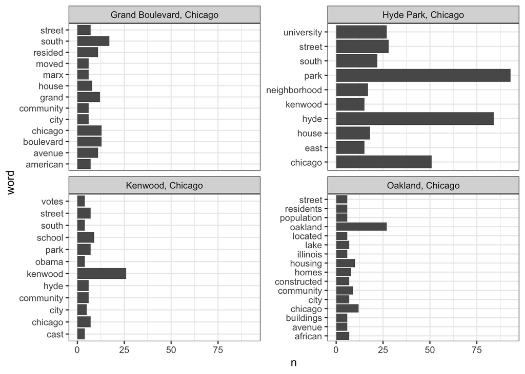

```r
ggplot(tokens_area) +
  geom_col(aes(x = n, y = word)) +
  facet_wrap(. ~ name, ncol = 2, scales = "free_y") +
  theme_bw()
```

There are some similarities and differences between these locations.

All of them show words “Chicago,” and “street”, along with names relevant to their specific areas, such as “grand”, “boulevard”, “hyde”, “kenwood”, and “oakland”, reflecting a consistent interest in local addresses and the city itself. Meanwhile, words like “souch” and “avenue”, though look different, both indicate their geographical positions. For instance, “south” appears in Grand Boulevard, Hyde Park, and Kenwood, reflecting their geographical location is further south to downtown Chicago, while Oakland, located in north, lacks this word. Additionally, “park” is another common word used in both Hyde Park and Kenwood, fitting given their neighboring positions and the presence of parks in both areas. This may also explain these two areas share the other’s name in their searches. Such alignment of common words with their geographical locations show how these words are prominent features of the areas. Furthermore, three of these locations share the word “community”, with Hyde Park uniquely using “neighborhood”, highlighting their shared focus on neighborhood identity and community engagement.

Interestingly, both Kenwood and Grand Boulevard include notable names “Obama” and “Marx”. Even though they are not the same name, they exactly suggest the featured notable figures who lived or have lived in the corresponding areas. To be specific, the former President Barack Obama resides in Kenwood, while the famous American family comedy act, the Marx Brothers once lived in Grand Boulevard.

Noticeably, Oakland stands out with words of “homes”, “housing”, “residents”, “constructed”, “building” that are specific to residential aspects and living situations; however, the others focus on more general area. As a matter of fact, Oakland is the area that situates closest to central Chicago.

```r
place = html_attr(place_elements, "title")
base_url <- "https://en.wikipedia.org/wiki/"
print(place)


get_main_text <- function(url) {
  url %>%
    read_html() %>%
    html_nodes(css = ".mw-parser-output p") %>%
    html_text()
}

all_text <- c()

for (area in place) {

  area_formatted <- area %>%
    gsub(" ", "_", .)
  full_url <- paste0(base_url, area_formatted)
  print(full_url)

  area_text <- get_main_text(full_url)
  area_text_combined <- paste(area_text, collapse = " ")
  clean_area_text <- gsub("\\[.*?\\]", "", area_text_combined)
  all_text <- c(all_text, clean_area_text)
}

final_all_text <- paste(all_text, collapse = "\n\n")

cat(final_all_text)
```

[output not shown]